# Coursework Report

*N* removed NAs: 3

*N* removed typo: 1

*N* removed <18: 30

*N* total clean: 116

| Group | *N* | *M*<sub>age</sub> | *M*<sub>rating</sub> |
| --- | --- | --- | --- |
| Control | 61 | 21.11 | 6.42 |
| Experim | 55 | 20.36 | 7.01 |

**Main analysis results**

*t*(114) = -3.88, *p* < .001

[interactive chart not shown]

[figure not shown]

[interactive chart not shown]

# Coursework Report

Analysing Data, Spring 2020

# Methods

## Participants

Figure 1: Summary of participants by Condition

| Condition | *M*<sub>age</sub> | *SD*<sub>age</sub> |
| --- | --- | --- |
| control | 21.11 | 1.86 |
| experimental | 20.36 | 1.69 |

## Design

This research data will be used to see if the colour of a frame red or white would influence a participant’s perception of attractiveness. The conditions were based on the colour of the background given to the participant, if ID was in the control level, they had a white background, if they were in the experimental condition then they had a red background. The question variables were all ratings of the three questions given based on a scale of 1-9, the higher the rating given the more attractive the participants found the pictures, this is a replication of (Elliot et al 2010) study one. Overall, the experimental condition should indicate a higher attraction rating, we will test this with the T test.

# Results

Overall by examining the basic means of the data it can be demonstrated that they are relatively similar to one another (see Figure 2) this implies that similar ratings were given no matter the colour of the background, however the fact that the experimental value is higher it does suggest that no matter how small the difference participants in the experimental condition would rate pictures higher. The standard deviation of each condition suggests that all ratings were similar. A mean composition was conducted to use in the t.test which found similar ratings throughout the results. The t test conducted helped demonstrate this as seen by the results (*M*<sub>diff</sub> = 0.59, 95% CI [-0.89, -0.29] *t* (114) = -3.88 p < .001. The difference in the means is relatively small but could still be considered significant as the p value is very small so the alternative hypothesis can be accepted.

Figure 2: Attraction Rating by Condition

[output not shown]

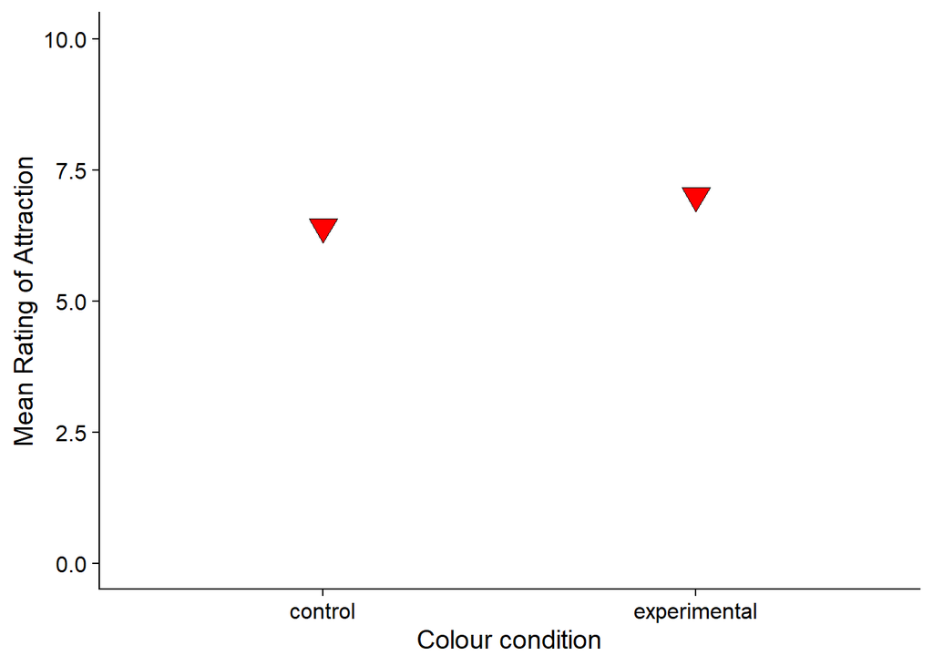

[output not shown]